# Filtering Phage and Plasmid Output from geNomad

## 2.4 2.4 Filter

A reasonable first pass is to remove very short contigs, which are the most likely to be assembly fragments rather than real, complete viral genomes:

```r
# I will filter out viruses smaller than 5000bp
phage_inferences_filtered <- phage_inferences %>%
  filter(contig_length > 5000)

# let's see how many we have left
dim(phage_inferences_filtered)
```

```
## [1] 20600    31
```

You can tighten or loosen this filter depending on how conservative you want to be. Combining two criteria with a comma (or `&`) requires **both** to be true (stricter, fewer sequences kept); combining them with `|` requires **either** to be true (more lenient, more sequences kept):

```r
# We can be more strict, I want them also to have more than two viral genes
phage_inferences_filtered_strict <- phage_inferences %>%
  filter(contig_length > 5000, viral_genes > 2)

# Or less strict, I want them to be >5000bp OR to have more than 2 viral genes
phage_inferences_filtered_lenient <- phage_inferences %>%
  filter(contig_length > 5000 | viral_genes > 2)
```

# 3 3. Plasmids

Let’s now look at the plasmids!

## 3.1 3.1 Load Data

```r
plasmid_inferences <- read_csv("~/Documents/GitHub/ucd_bioinformaticscourse_2026/data/plasmids_summary.csv")
```

## 3.2 3.2 Inspect Data

```r
summary(plasmid_inferences)
```

```
##    seq_name             length         topology            n_genes
##  Length:679624      Min.   :   200   Length:679624      Min.   :  1.000
##  Class :character   1st Qu.:   417   Class :character   1st Qu.:  1.000
##  Mode  :character   Median :   678   Mode  :character   Median :  2.000
##                     Mean   :  1757                      Mean   :  2.651
##                     3rd Qu.:  2502                      3rd Qu.:  3.000
##                     Max.   :128256                      Max.   :134.000
##                     NA's   :1                           NA's   :1
##   genetic_code   plasmid_score      fdr           n_hallmarks
##  Min.   : 4.00   Min.   :0.7000   Mode:logical   Min.   : 0.0000
##  1st Qu.:11.00   1st Qu.:0.9881   NA's:679624    1st Qu.: 1.0000
##  Median :11.00   Median :0.9996                  Median : 1.0000
##  Mean   :10.97   Mean   :0.9750                  Mean   : 0.8716
##  3rd Qu.:11.00   3rd Qu.:0.9999                  3rd Qu.: 1.0000
##  Max.   :15.00   Max.   :1.0000                  Max.   :19.0000
##  NA's   :1       NA's   :1                       NA's   :1
##  marker_enrichment conjugation_genes   amr_genes
##  Min.   : 0.1001   Length:679624      Length:679624
##  1st Qu.: 1.0785   Class :character   Class :character
##  Median : 1.3758   Mode  :character   Mode  :character
##  Mean   : 1.5834
##  3rd Qu.: 1.7183
##  Max.   :82.5700
##  NA's   :1
```

## 3.3 3.3 Explore

We use this exploration to choose filter parameters, the same way we did for phages.

### 3.3.1 Length

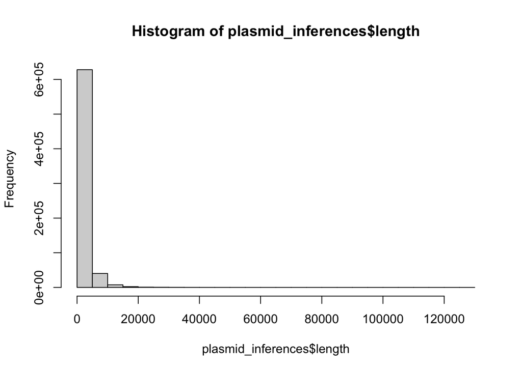

```r
hist(plasmid_inferences$length)
```

```r
summary(plasmid_inferences$length)
```

```
##    Min. 1st Qu.  Median    Mean 3rd Qu.    Max.    NA's
##     200     417     678    1757    2502  128256       1
```

### 3.3.2 Plasmid Score

`plasmid_score` is geNomad’s confidence score for plasmid classification, ranging from 0 to 1. It’s typically the single most useful filtering variable for plasmids, since it directly reflects how confident geNomad is that a sequence is really a plasmid rather than a chromosomal fragment.

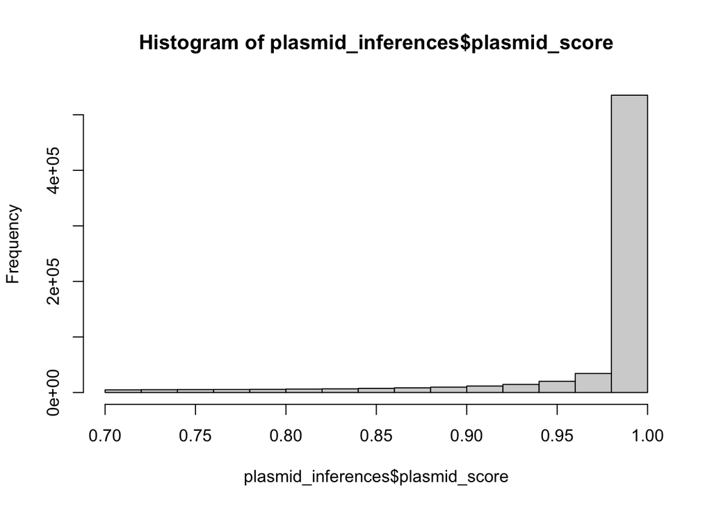

```r
hist(plasmid_inferences$plasmid_score)
```

```r
summary(plasmid_inferences$plasmid_score)
```

```
##    Min. 1st Qu.  Median    Mean 3rd Qu.    Max.    NA's
##  0.7000  0.9881  0.9996  0.9750  0.9999  1.0000       1
```

### 3.3.3 Topology

```r
# How many of each topology?
plasmid_inferences %>% count(topology)
```

```
## # A tibble: 4 × 2
##   topology                 n
##   <chr>                <int>
## 1 DTR                   2505
## 2 ITR                     39
## 3 No terminal repeats 677079
## 4 <NA>                     1
```

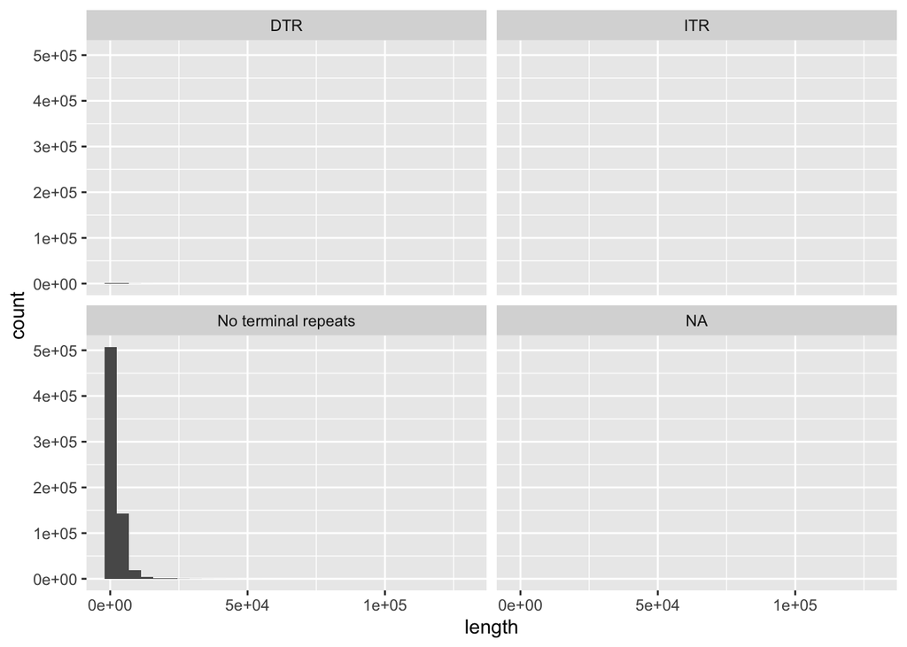

```r
# length distribution separated by topology
ggplot(plasmid_inferences, aes(x = length)) +
  geom_histogram() +
  facet_wrap(~topology)
```

Circular plasmids represent complete, closed sequences, while linear ones are often assembly fragments of larger circular plasmids that didn’t fully resolve. If most of your short sequences are linear, that’s a sign your length filter is also indirectly filtering out incomplete plasmids.

### 3.3.4 Number of Genes

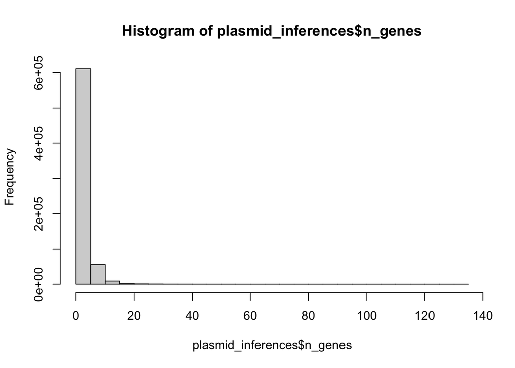

```r
hist(plasmid_inferences$n_genes)
```

```r
summary(plasmid_inferences$n_genes)
```

```
##    Min. 1st Qu.  Median    Mean 3rd Qu.    Max.    NA's
##   1.000   1.000   2.000   2.651   3.000 134.000       1
```

### 3.3.5 Score vs. Length

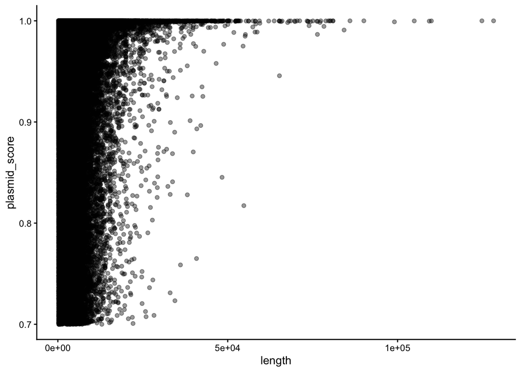

```r
ggplot(plasmid_inferences, aes(x = length, y = plasmid_score)) +
  geom_point(alpha = 0.4) +
  theme_classic()
```

**Reading this scatterplot:** this lets you check whether `plasmid_score` and `length` are giving you redundant or complementary information. If short sequences cluster at low scores, length and score are telling you roughly the same thing, and filtering on one largely covers the other. If you instead see short sequences with high scores (or long sequences with low scores), the two metrics are capturing different kinds of uncertainty, and combining them with an AND/OR filter (as below) becomes more meaningful.

## 3.4 3.4 Filter

```r
# I will filter out plasmids with a low plasmid_score
plasmid_inferences_filtered <- plasmid_inferences %>%
  filter(plasmid_score > 0.8)

# let's see how many we have left
dim(plasmid_inferences_filtered)
```

```
## [1] 653642     11
```

```r
# We can be more strict: score AND a minimum length
plasmid_inferences_filtered_strict <- plasmid_inferences %>%
  filter(plasmid_score > 0.8, length > 1000)

# Or less strict: score OR a minimum length
plasmid_inferences_filtered_lenient <- plasmid_inferences %>%
  filter(plasmid_score > 0.8 | length > 1000)
```

# 4 4. Quantifying Filter Permissiveness

So far we’ve applied a handful of filters one at a time and looked at how many sequences survived each one with `dim()`. That tells you the result of a single choice, but not how sensitive that result is to the choice itself. In this section we systematically compare filters side by side, and sweep across a *range* of thresholds, so you can see exactly where your dataset is robust to the cutoff you choose and where it’s fragile (i.e. where small changes in threshold cause big swings in how many sequences you keep).

A quick technical note before we start: some geNomad output columns can contain a stray missing value (`NA`), and functions like `sum()` will propagate that single `NA` across an entire calculation unless you tell them to ignore it. That’s why you’ll see `na.rm = TRUE` used throughout below — without it, a single missing value can silently turn your whole result into `NA`, which can look like a bug in your code when it’s really just an unhandled missing value in the data.

## 4.1 4.1 Phages

### 4.1.1 Comparing Named Filters Side by Side

```r
phage_filters <- list(
  "no filter"          = function(df) df,
  "length > 5000"      = function(df) filter(df, contig_length > 5000),
  "strict (AND)"       = function(df) filter(df, contig_length > 5000, viral_genes > 2),
  "lenient (OR)"       = function(df) filter(df, contig_length > 5000 | viral_genes > 2)
)

phage_filter_summary <- map_dfr(names(phage_filters), function(filter_name) {
  filtered <- phage_filters[[filter_name]](phage_inferences)
  tibble(
    filter = filter_name,
    n_retained = nrow(filtered),
    pct_retained = round(100 * nrow(filtered) / nrow(phage_inferences), 1)
  )
})

phage_filter_summary
```

```
## # A tibble: 4 × 3
##   filter        n_retained pct_retained
##   <chr>              <int>        <dbl>
## 1 no filter         156709        100
## 2 length > 5000      20600         13.1
## 3 strict (AND)        8445          5.4
## 4 lenient (OR)       39414         25.2
```

**Reading this table:** this puts all your filtering decisions in one place so you can compare percentage retained at a glance, rather than re-running `dim()` after each filter and trying to remember the previous number.

### 4.1.2 Threshold Sweep: Contig Length

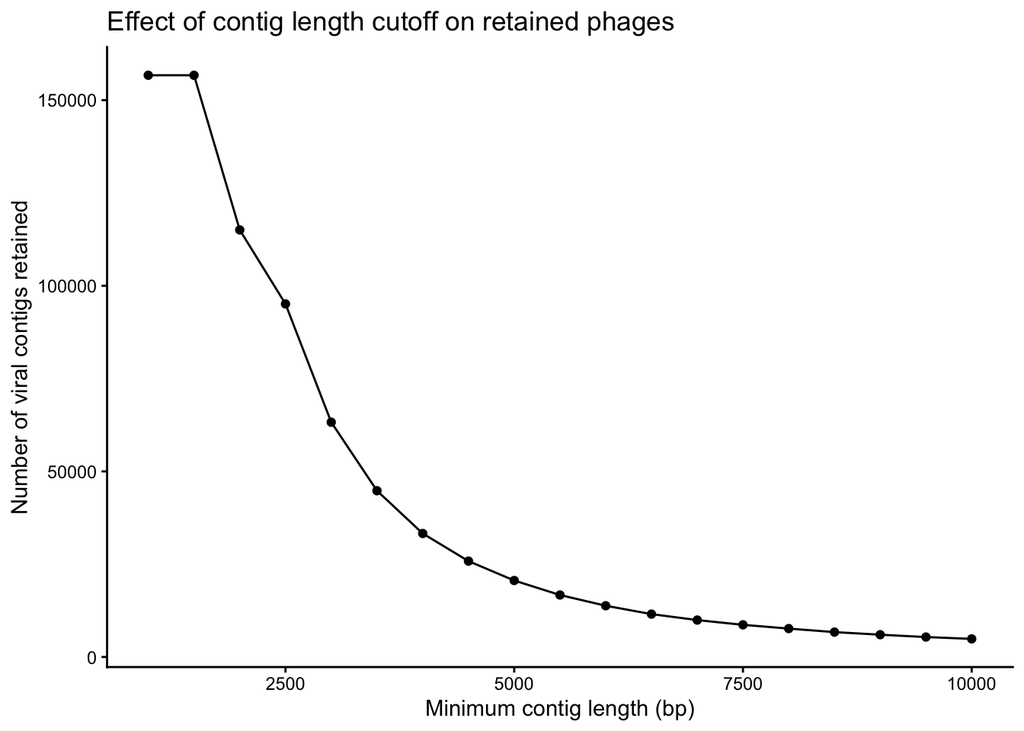

```r
length_thresholds <- seq(1000, 10000, by = 500)

phage_length_sweep <- map_dfr(length_thresholds, function(thresh) {
  tibble(
    threshold = thresh,
    n_retained = sum(phage_inferences$contig_length > thresh, na.rm = TRUE)
  )
})

ggplot(phage_length_sweep, aes(x = threshold, y = n_retained)) +
  geom_line() +
  geom_point() +
  xlab("Minimum contig length (bp)") +
  ylab("Number of viral contigs retained") +
  ggtitle("Effect of contig length cutoff on retained phages") +
  theme_classic()
```

**Reading this plot:** a steep drop in the curve tells you that many contigs cluster right around that length, so your final count is very sensitive to where exactly you set the cutoff there. A flatter stretch of the curve means the choice of cutoff matters less in that range, since few sequences sit right at the boundary. Look for a “knee” in the curve — a flatter region after an initial steep drop is often a good place to set a defensible threshold, since it means you’re not sitting on a knife-edge decision.

### 4.1.3 Threshold Sweep: Viral Gene Count

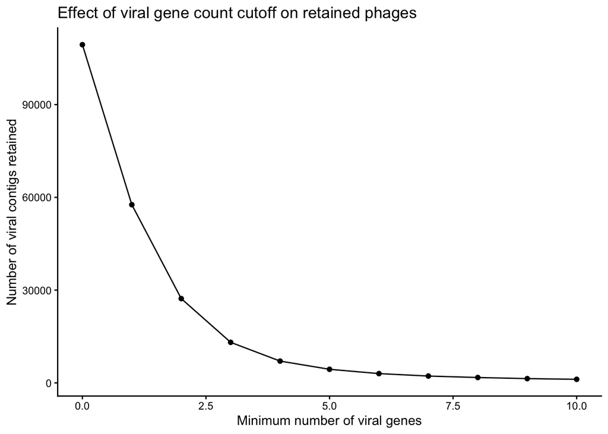

```r
gene_thresholds <- seq(0, 10, by = 1)

phage_gene_sweep <- map_dfr(gene_thresholds, function(thresh) {
  tibble(
    threshold = thresh,
    n_retained = sum(phage_inferences$viral_genes > thresh, na.rm = TRUE)
  )
})

ggplot(phage_gene_sweep, aes(x = threshold, y = n_retained)) +
  geom_line() +
  geom_point() +
  xlab("Minimum number of viral genes") +
  ylab("Number of viral contigs retained") +
  ggtitle("Effect of viral gene count cutoff on retained phages") +
  theme_classic()
```

### 4.1.4 Combined Sweep: AND vs. OR Logic

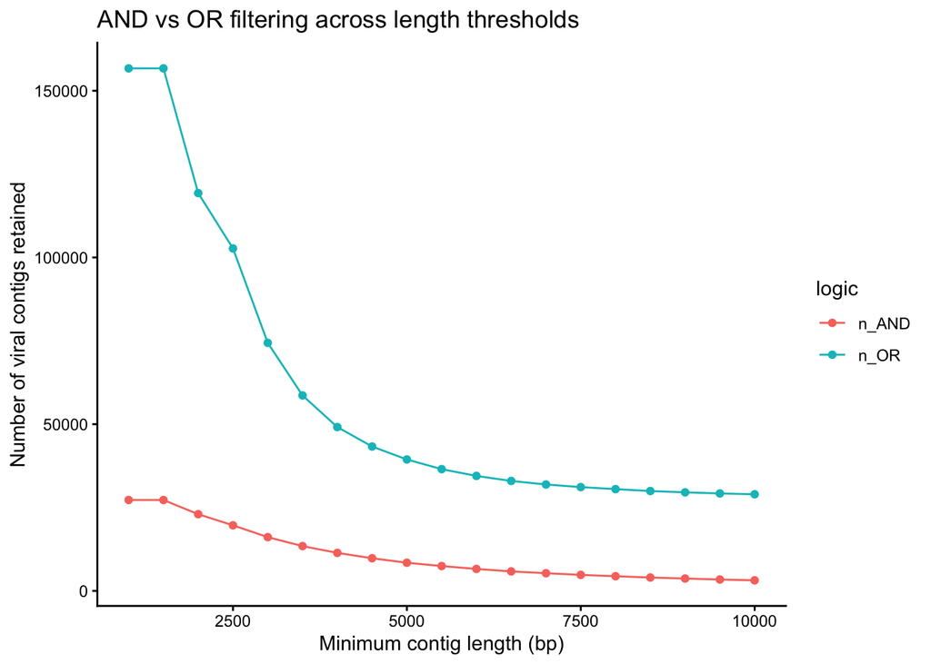

```r
phage_combined_sweep <- map_dfr(length_thresholds, function(thresh) {
  tibble(
    threshold = thresh,
    n_AND = sum(phage_inferences$contig_length > thresh & phage_inferences$viral_genes > 2, na.rm = TRUE),
    n_OR  = sum(phage_inferences$contig_length > thresh | phage_inferences$viral_genes > 2, na.rm = TRUE)
  )
}) %>%
  pivot_longer(cols = c(n_AND, n_OR), names_to = "logic", values_to = "n_retained")

ggplot(phage_combined_sweep, aes(x = threshold, y = n_retained, color = logic)) +
  geom_line() +
  geom_point() +
  xlab("Minimum contig length (bp)") +
  ylab("Number of viral contigs retained") +
  ggtitle("AND vs OR filtering across length thresholds") +
  theme_classic()
```

**Reading this plot:** the gap between the AND and OR lines tells you how much your combination logic matters, independent of the threshold itself. A wide gap means the two criteria (length and gene count) are capturing different sequences, so whether you require both or either makes a real difference to your final dataset. A narrow gap means the two criteria are largely redundant — most sequences that pass one also pass the other, so the AND/OR choice barely matters and you could simplify your filter to a single criterion.

## 4.2 4.2 Plasmids

### 4.2.1 Comparing Named Filters Side by Side

```r
plasmid_filters <- list(
  "no filter"    = function(df) df,
  "score > 0.8"  = function(df) filter(df, plasmid_score > 0.8),
  "strict (AND)" = function(df) filter(df, plasmid_score > 0.8, length > 1000),
  "lenient (OR)" = function(df) filter(df, plasmid_score > 0.8 | length > 1000)
)

plasmid_filter_summary <- map_dfr(names(plasmid_filters), function(filter_name) {
  filtered <- plasmid_filters[[filter_name]](plasmid_inferences)
  tibble(
    filter = filter_name,
    n_retained = nrow(filtered),
    pct_retained = round(100 * nrow(filtered) / nrow(plasmid_inferences), 1)
  )
})

plasmid_filter_summary
```

```
## # A tibble: 4 × 3
##   filter       n_retained pct_retained
##   <chr>             <int>        <dbl>
## 1 no filter        679624        100
## 2 score > 0.8      653642         96.2
## 3 strict (AND)     245691         36.2
## 4 lenient (OR)     665368         97.9
```

### 4.2.2 Threshold Sweep: Plasmid Score

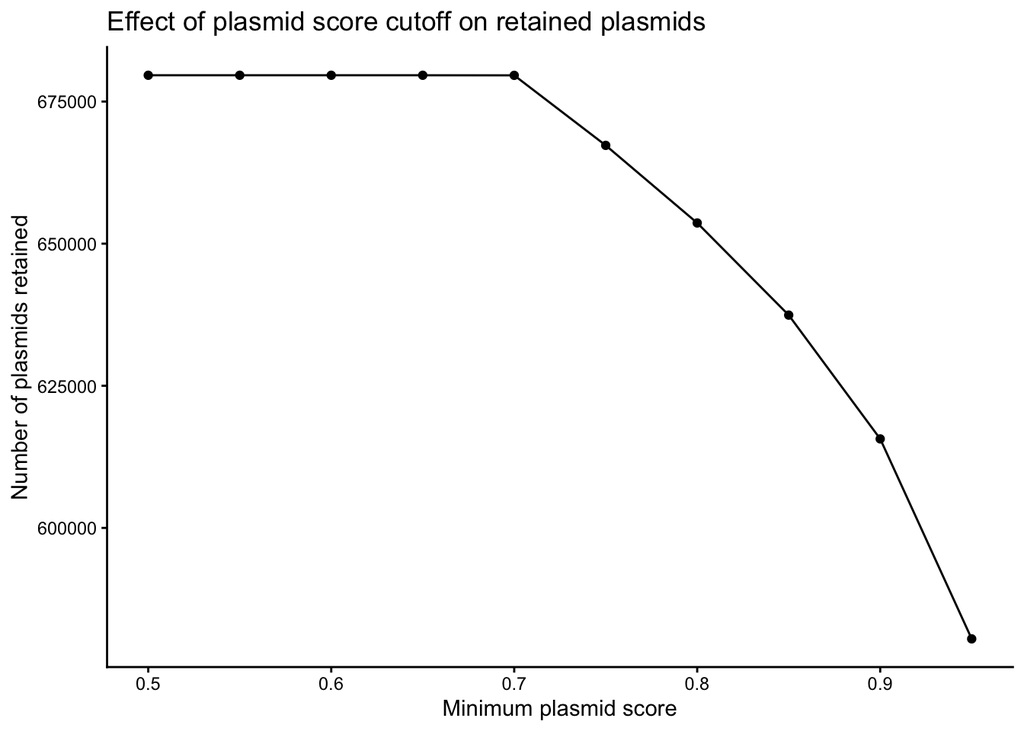

```r
score_thresholds <- seq(0.5, 0.95, by = 0.05)

plasmid_score_sweep <- map_dfr(score_thresholds, function(thresh) {
  tibble(
    threshold = thresh,
    n_retained = sum(plasmid_inferences$plasmid_score > thresh, na.rm = TRUE)
  )
})

ggplot(plasmid_score_sweep, aes(x = threshold, y = n_retained)) +
  geom_line() +
  geom_point() +
  xlab("Minimum plasmid score") +
  ylab("Number of plasmids retained") +
  ggtitle("Effect of plasmid score cutoff on retained plasmids") +
  theme_classic()
```

### 4.2.3 Threshold Sweep: Length

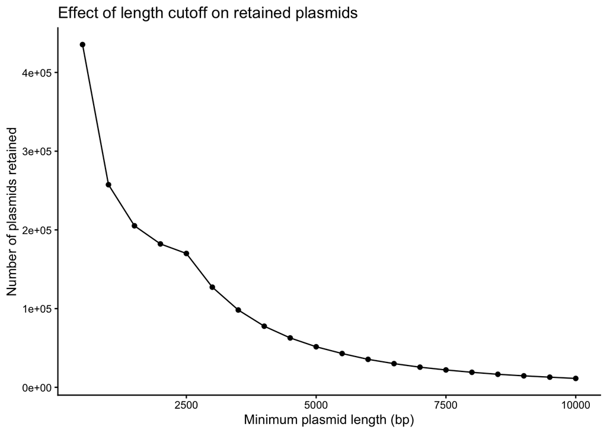

```r
plasmid_length_thresholds <- seq(500, 10000, by = 500)

plasmid_length_sweep <- map_dfr(plasmid_length_thresholds, function(thresh) {
  tibble(
    threshold = thresh,
    n_retained = sum(plasmid_inferences$length > thresh, na.rm = TRUE)
  )
})

ggplot(plasmid_length_sweep, aes(x = threshold, y = n_retained)) +
  geom_line() +
  geom_point() +
  xlab("Minimum plasmid length (bp)") +
  ylab("Number of plasmids retained") +
  ggtitle("Effect of length cutoff on retained plasmids") +
  theme_classic()
```

### 4.2.4 Combined Sweep: AND vs. OR Logic

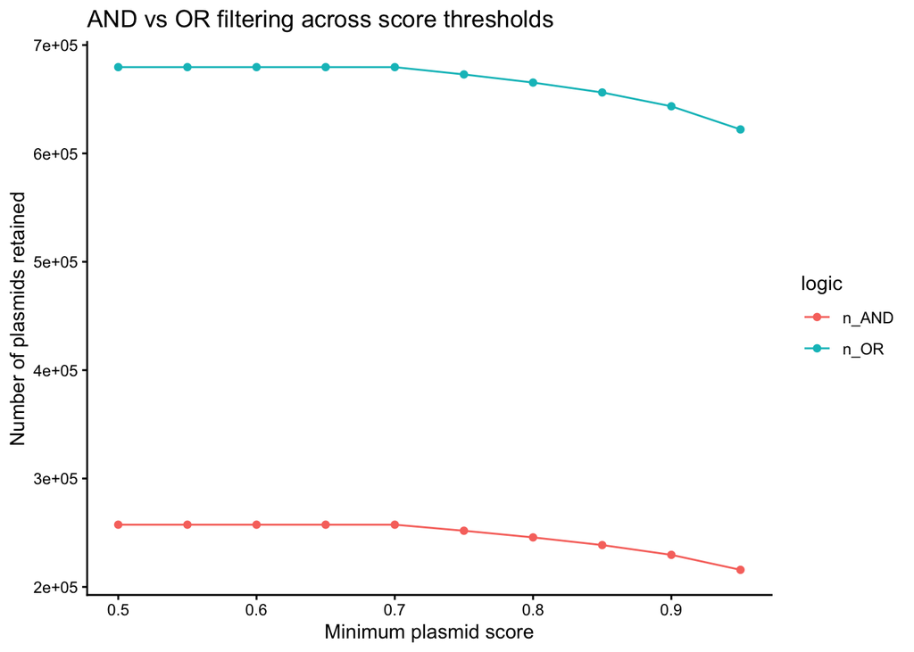

```r
plasmid_combined_sweep <- map_dfr(score_thresholds, function(thresh) {
  tibble(
    threshold = thresh,
    n_AND = sum(plasmid_inferences$plasmid_score > thresh & plasmid_inferences$length > 1000, na.rm = TRUE),
    n_OR  = sum(plasmid_inferences$plasmid_score > thresh | plasmid_inferences$length > 1000, na.rm = TRUE)
  )
}) %>%
  pivot_longer(cols = c(n_AND, n_OR), names_to = "logic", values_to = "n_retained")

ggplot(plasmid_combined_sweep, aes(x = threshold, y = n_retained, color = logic)) +
  geom_line() +
  geom_point() +
  xlab("Minimum plasmid score") +
  ylab("Number of plasmids retained") +
  ggtitle("AND vs OR filtering across score thresholds") +
  theme_classic()
```

# 5 5. Wrap-Up Discussion

After working through both sections, discuss with your group:

1. For phages, does length or gene count seem like the more “decisive” filtering variable — i.e. which one, when swept across thresholds, causes bigger swings in how many sequences are retained?
2. For plasmids, where does the `plasmid_score` sweep start to drop off steeply? Does that match where you’d intuitively want to draw the line between “confident” and “uncertain” calls?
3. Looking at the AND vs. OR plots for both groups: are your two filtering criteria mostly redundant, or do they capture meaningfully different sequences?
4. Based on everything above, what filtering thresholds would you choose for your own analysis, and how would you justify that choice to someone reviewing your work?